# Project 2

Michelle

2026-11-22

# Background

Sickle cell disease (SCD) is a group of genetic disorders in which red blood cells contort into a sickle shape. Symptoms of SCD include anemia (caused by misshapen cells dying early) as well as pain, infection, and stroke (caused by sickle cells blocking blood flow). There is some evidence that exposure to air pollution aggravates vaso-occlusion and pain in SCD patients.

A hematologist at Duke wants to study the associations between various air pollutants and SCD in Durham County, North Carolina. She provides data on health system utilization (i.e., emergency department visits, hospitalizations, etc.) for SCD and you obtain air pollution data from the EPA. The pollutant data are raw measurements taken from the air pollution monitor at the RDU airport. This exposure data is messy and will need to be processed. You will write a function to process your data and do some exploratory data analysis (EDA) using tables and plots.

**Github Link:** [Github](https://github.com/m8liaang/biostatistics-coursework)

# Function

**Think carefully about the order in which your function does these steps. Does the order change your results?**

Yes, the order can change the results as some steps can influence subsequent calculations. For example, performing the average calculations before removing negative and duplicate values would result in incorrect averages. Converting the date format before grouping is also better as it ensures the observations corresponding to the same date are grouped together even if the formats are different.

## Tables

**Table One**: A table showing the pollutant concentrations for 2018, in ppm.

| Maximum (Max.) and Minimum (Min.) Pollutant Concentrations (Conc.) for 2018 Year | Maximum (Max.) and Minimum (Min.) Pollutant Concentrations (Conc.) for 2018 Min. CO Conc. (ppm) | Maximum (Max.) and Minimum (Min.) Pollutant Concentrations (Conc.) for 2018 Maximum CO Conc. (ppm) | Maximum (Max.) and Minimum (Min.) Pollutant Concentrations (Conc.) for 2018 Min. PM2.5 Conc. (µg/m³ LC) | Maximum (Max.) and Minimum (Min.) Pollutant Concentrations (Conc.) for 2018 Max. PM2.5 Conc. (µg/m³ LC) | Maximum (Max.) and Minimum (Min.) Pollutant Concentrations (Conc.) for 2018 Min. O3 (Ozone) Conc. (ppm) | Maximum (Max.) and Minimum (Min.) Pollutant Concentrations (Conc.) for 2018 Max. O3 (Ozone) Conc. (ppm) |
| --- | --- | --- | --- | --- | --- | --- |
| 2018 | 0.100 | 1.000 | 0.000 | 20.400 | 0.012 | 0.067 |

**Table Two**: A table showing the pollutant concentrations for 2019, in ppm.

| Maximum (Max.) and Minimum (Min.) Pollutant Concentrations (Conc.) for 2019 Year | Maximum (Max.) and Minimum (Min.) Pollutant Concentrations (Conc.) for 2019 Min. CO Conc. (ppm) | Maximum (Max.) and Minimum (Min.) Pollutant Concentrations (Conc.) for 2019 Maximum CO Conc. (ppm) | Maximum (Max.) and Minimum (Min.) Pollutant Concentrations (Conc.) for 2019 Min. PM2.5 Conc. (µg/m³ LC) | Maximum (Max.) and Minimum (Min.) Pollutant Concentrations (Conc.) for 2019 Max. PM2.5 Conc. (µg/m³ LC) | Maximum (Max.) and Minimum (Min.) Pollutant Concentrations (Conc.) for 2019 Min. O3 (Ozone) Conc. (ppm) | Maximum (Max.) and Minimum (Min.) Pollutant Concentrations (Conc.) for 2019 Max. O3 (Ozone) Conc. (ppm) |
| --- | --- | --- | --- | --- | --- | --- |
| 2019 | 0.100 | 1.300 | 1.400 | 21.300 | 0.015 | 0.068 |

**Table Three**: A table showing the pollutant concentrations for 2020, in ppm.

| Maximum (Max.) and Minimum (Min.) Pollutant Concentrations (Conc.) for 2020 Year | Maximum (Max.) and Minimum (Min.) Pollutant Concentrations (Conc.) for 2020 Min. CO Conc. (ppm) | Maximum (Max.) and Minimum (Min.) Pollutant Concentrations (Conc.) for 2020 Maximum CO Conc. (ppm) | Maximum (Max.) and Minimum (Min.) Pollutant Concentrations (Conc.) for 2020 Min. PM2.5 Conc. (µg/m³ LC) | Maximum (Max.) and Minimum (Min.) Pollutant Concentrations (Conc.) for 2020 Max. PM2.5 Conc. (µg/m³ LC) | Maximum (Max.) and Minimum (Min.) Pollutant Concentrations (Conc.) for 2020 Min. O3 (Ozone) Conc. (ppm) | Maximum (Max.) and Minimum (Min.) Pollutant Concentrations (Conc.) for 2020 Max. O3 (Ozone) Conc. (ppm) |
| --- | --- | --- | --- | --- | --- | --- |
| 2020 | 0.100 | 1.000 | 0.300 | 31.200 | 0.010 | 0.052 |

## Plot 1: CO and O3 by month.

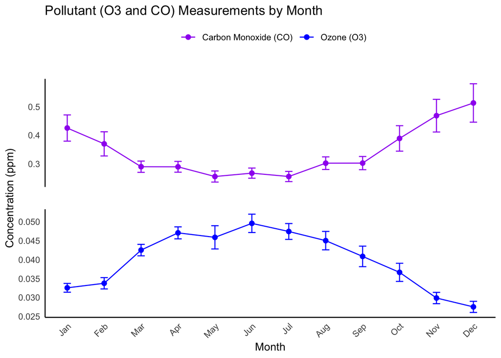

Note: Because the 2020 data stops in April, the averages for January-April are based on three years of data, while May-December are only based on two.

The concentrations for CO and O3, while in the same units, are on very different scales, so the two variables were graphed separately before being combined them into a single image. With this method, both of their scales were accounted for while allowing their graphs to be viewed side-by-side to visually see their differences.

## Plot 2: PM2.5 by month and year.

Month on the x-axis and PM2.5 concentration on the y-axis. Include year as different colors. Use whatever geom you think best displays the data. There is no “correct” geom, but some are better than others. Consider readability - what conveys any patterns in your data best? Below the plot, write a 1-sentence justification of your choice of geom.

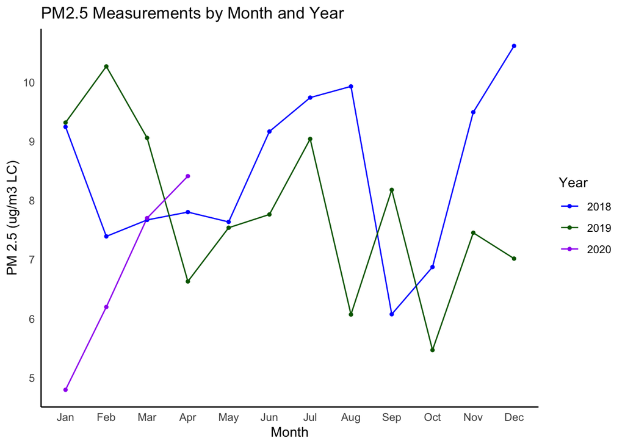

I chose to graph it with a connected scatterplot as I felt it was a good way to show how the concentrations of PM2.5 change over time.

## Interpretation

**In 2-3 sentences, describe the patterns you see in your tables and plots. For example: Do any pollutants show seasonal patterns? Do any years stand out? Keep in mind which months have less data.**

Plot 1 suggests that ozone concentrations increase during the warmer seasons (spring and summer) compared to the colder months, while carbon monoxide concentrations see the opposite trend (increase in the colder months, and decrease in the warmer ones). Plot 2 suggests that the changes in PM2.5 concentration is more varied, though sharp increases are seen in the colder months (as shown for all three years) as well as in the summer (as seen in 2018 and 2019). As a result, Plot 1 indicates that ozone and carbon monoxide show a seasonal pattern, while PM2.5 shows a more complex and varied one.